# Thesis Benchmark Implementation: Robust Deep Learning

This notebook implements the baseline algorithms for comparison against the proposed algorithm.

The goal is to reproduce the performance of standard and existing robust methods on datasets with known noise.

## 1. Imports

We'll begin by importing the necessary libraries from PyTorch, TorchVision, and NumPy.

```python
# --- 1. Imports ---

import torch
import torch.nn as nn
import torch.optim as optim
import torch.nn.functional as F
from torch.utils.data import DataLoader, Dataset
import torchvision
import torchvision.transforms as transforms

import numpy as np
import matplotlib.pyplot as plt
import random
from tqdm.notebook import tqdm  # For progress bars

# Set a random seed for reproducibility
seed = 42
torch.manual_seed(seed)
np.random.seed(seed)
random.seed(seed)

# --- Updated Device Setup ---
if torch.cuda.is_available():
    device = torch.device("cuda")
    torch.cuda.manual_seed_all(seed)
    torch.backends.cudnn.deterministic = True
    torch.backends.cudnn.benchmark = False
elif torch.backends.mps.is_available():
    # This is for Apple's M-series chips
    device = torch.device("mps")
else:
    device = torch.device("cpu")

print(f"Using device: {device}")
```

```
Using device: mps
```

```python
# --- Mount Drive (Colab) or Define Local Path (Local) ---
import os

# Check if we are in Google Colab
try:
    import google.colab
    IS_COLAB = True
except ImportError:
    IS_COLAB = False

if IS_COLAB:
    print("Running on Google Colab. Mounting Drive...")
    from google.colab import drive
    drive.mount('/content/drive')
    # Use the Google Drive path
    checkpoint_dir = '/content/drive/MyDrive/ThesisCheckpoints'
else:
    print("Running locally. Using local checkpoint directory.")
    # Use a local folder named 'ThesisCheckpoints' in your notebook's directory
    checkpoint_dir = './ThesisCheckpoints'

# --- This part is the same for both ---
# Ensure the directory exists
if not os.path.exists(checkpoint_dir):
    os.makedirs(checkpoint_dir)
    print(f"Created directory: {checkpoint_dir}")
else:
    print(f"Checkpoint directory already exists: {checkpoint_dir}")
```

```
Running locally. Using local checkpoint directory.
Checkpoint directory already exists: ./ThesisCheckpoints
```

## 2. Baseline 1: Uniform SGD

This is the standard, non-robust training procedure. It serves as our main baseline.

- **Method:** Standard Stochastic Gradient Descent (or Adam, etc.).
- **Sampling:** Samples are drawn *uniformly at random* from the entire training dataset in each epoch (as handled by the default `DataLoader`).
- **Behavior:** This method is expected to eventually overfit the noisy labels/samples, leading to a drop in validation/test accuracy. We will define a standard training function for one epoch.

```python
# --- 2. Baseline 1: Uniform SGD ---

def train_uniform_sgd(model, train_loader, criterion, optimizer, device):
    """
    Standard training loop for one epoch using Uniform SGD.
    non-robust baseline.
    """
    model.train()  # Set the model to training mode
    running_loss = 0.0
    correct_samples = 0
    total_samples = 0

    # The default train_loader already implements uniform random sampling
    # (with shuffling enabled)
    for inputs, labels in train_loader:

        # Move data to the configured device
        inputs, labels = inputs.to(device), labels.to(device)

        # 1. Zero the parameter gradients
        optimizer.zero_grad()

        # 2. Forward pass
        outputs = model(inputs)

        # 3. Calculate the loss
        # Note: We use the raw, unreduced loss for potential future per-sample analysis,
        # but for the step, we need the mean.
        # For Uniform SGD, we just use the standard reduction ('mean').
        # We ensure the criterion is set to 'mean' reduction outside this function.
        loss = criterion(outputs, labels)

        # 4. Backward pass
        loss.backward()

        # 5. Optimize
        optimizer.step()

        # --- Statistics ---
        running_loss += loss.item() * inputs.size(0)

        # Calculate accuracy
        _, predicted = torch.max(outputs.data, 1)
        total_samples += labels.size(0)
        correct_samples += (predicted == labels).sum().item()

    epoch_loss = running_loss / total_samples
    epoch_acc = correct_samples / total_samples

    return epoch_loss, epoch_acc
```

## 3. Baseline 2: Min-k Loss SGD (MKL-SGD)

This is our first robust baseline, based on the paper **"Choosing the Sample with Lowest Loss makes SGD Robust"**.

To do this, we will need a separate loss function (criterion) instantiated with `reduction='none'` to get the per-sample losses.

```python
# --- 3. Baseline 2: MKL-SGD ---

def train_mkl_sgd(model, train_loader, criterion_nored, optimizer, device, k_ratio=2.0):
    """
    Training loop for one epoch using Min-k Loss SGD (MKL-SGD).
    Based on the "practical batched variant" from the paper[cite: 355].

    Args:
        model: The neural network.
        train_loader: DataLoader for training data.
        criterion_nored: Loss function (e.g., CrossEntropyLoss)
                         initialized with `reduction='none'`.
        optimizer: The optimizer (e.g., SGD, Adam).
        device: The device to run on (cpu or cuda).
        k_ratio: The denominator for sample selection (e.g., 2.0 means b/2 samples).
    """
    model.train()
    running_selected_loss = 0.0
    correct_samples = 0
    total_samples = 0
    total_selected_samples = 0

    for inputs, labels in train_loader:

        inputs, labels = inputs.to(device), labels.to(device)
        batch_size = inputs.size(0)

        # Determine number of samples to select (m = b/k)
        # Ensure we select at least one sample
        num_to_select = int(batch_size / k_ratio)
        if num_to_select == 0:
            num_to_select = 1

        # 1. Zero the parameter gradients
        optimizer.zero_grad()

        # 2. Forward pass
        outputs = model(inputs)

        # 3. Calculate per-sample loss (reduction='none' is required)
        per_sample_loss = criterion_nored(outputs, labels)

        # 4. Select the m = b/k samples with the lowest loss
        sorted_loss, sorted_indices = torch.sort(per_sample_loss)
        selected_loss = sorted_loss[:num_to_select]

        # 5. Calculate the mean loss *only* for the selected samples
        mean_selected_loss = selected_loss.mean()

        # 6. Backward pass and optimize on the selected mean loss
        mean_selected_loss.backward()
        optimizer.step()

        # --- Statistics ---
        # We track the loss of the selected samples
        running_selected_loss += selected_loss.sum().item()
        total_selected_samples += num_to_select

        # Accuracy is calculated on the entire batch for a fair comparison
        _, predicted = torch.max(outputs.data, 1)
        total_samples += labels.size(0)
        correct_samples += (predicted == labels).sum().item()

    # Average loss over all *selected* samples
    epoch_loss = running_selected_loss / total_selected_samples

    # Average accuracy over *all* processed samples
    epoch_acc = correct_samples / total_samples

    return epoch_loss, epoch_acc
```

## 4. Baseline 3: Reducible Holdout Loss (RHO-LOSS)

This is the second robust baseline, based on the paper **"Prioritized Training on Points that are learnable, Worth Learning, and Not Yet Learnt"**. This method is a key inspiration for your thesis.

  **Phase 1: Pre-Computation (Done Once)**
  1. A holdout set $\mathcal{D}_{ho}$ is set aside.
  2. The **IL Model** is trained *only* on this holdout set $\mathcal{D}_{ho}$.
  3. We then perform a *single forward pass* of the entire training dataset through the (frozen) **IL Model** to calculate the loss for every single training sample $(x_i, y_i)$ .
  4. This loss, $L[y_i|x_i; \mathcal{D}_{ho}]$, is called the **Irreducible Loss (IL)**. It represents the "unlearnable" part of the sample, (e.g., noise). These values are stored in an array.

  **Phase 2: Main Training Loop**
  1. At each step, a large "candidate" batch $B_t$ (size $n_B$) is loaded.
  2. The **Target Model** calculates the *current training loss* for each sample in $B_t$: $L[y_i|x_i; \mathcal{D}_{t}]$.
  3. The **RHO-LOSS score** is computed for each sample: `RHO-LOSS[i] = Current_Loss[i] - IL[i]`.
  4. The algorithm selects the $n_b$ samples with the **highest** RHO-LOSS scores.
  5. A gradient step is performed using the *mean* of the `Current_Loss` (not the RHO-LOSS) of these $n_b$ selected samples.

```python
# --- 4. Baseline 3: RHO-LOSS (Phase 1: IL Pre-computation) ---
# [CORRECTED VERSION]

def compute_irreducible_loss(il_model, train_dataset, criterion_nored, device, batch_size=128):
    """
    Computes the Irreducible Loss (IL) for every sample in the train_dataset
    using the pre-trained il_model.

    Args:
        il_model: The pre-trained Irreducible Loss model.
        train_dataset: The *entire* training dataset object.
        criterion_nored: Loss function (reduction='none').
        device: CPU or CUDA.
        batch_size: Batch size for this one-time forward pass.

    Returns:
        A NumPy array containing the IL for each training sample, in order.
    """
    il_model.eval()  # Set IL model to evaluation mode
    all_il_losses = []

    # Use a DataLoader to process the dataset efficiently
    # IMPORTANT: shuffle=False to maintain dataset order
    il_loader = DataLoader(train_dataset, batch_size=batch_size, shuffle=False, num_workers=4)

    print("Computing Irreducible Losses (IL) for all training samples...")
    with torch.no_grad():  # No gradients needed

        # --- THE FIX IS HERE ---
        # The loader yields (data, label, index). We must unpack all three.
        # We can use '_' to ignore the index.
        for inputs, labels, _ in tqdm(il_loader, desc="IL Computation"):
            inputs, labels = inputs.to(device), labels.to(device)

            # Forward pass through the IL model
            outputs = il_model(inputs)

            # Calculate per-sample loss
            loss = criterion_nored(outputs, labels)

            all_il_losses.append(loss.cpu())

    # Concatenate all batch losses into a single tensor
    il_loss_map = torch.cat(all_il_losses).numpy()

    # Add a check to make sure the map size matches the dataset
    if len(il_loss_map) != len(train_dataset):
        print(f"Warning: IL map size ({len(il_loss_map)}) does not match"
              f" dataset size ({len(train_dataset)}). Check for errors.")

    print(f"Computed IL map with shape: {il_loss_map.shape}")
    return il_loss_map
```

```python
# --- 4. Baseline 3: RHO-LOSS (Phase 2: Training Loop) ---

def train_rho_loss(model, il_loss_map, train_loader, criterion_nored, optimizer, device, selection_ratio=0.1):
    """
    Training loop for one epoch using RHO-LOSS selection.

    Args:
        model: The main target model to train.
        il_loss_map: The NumPy array of pre-computed Irreducible Losses.
        train_loader: DataLoader. IMPORTANT: Must yield (inputs, labels, indices).
        criterion_nored: Loss function (reduction='none').
        optimizer: The optimizer.
        device: CPU or CUDA.
        selection_ratio: Ratio of samples to select (nb / nB).
                         [cite: 1052] (e.g., 0.1 for 10%)
    """
    model.train()
    running_selected_loss = 0.0
    correct_samples = 0
    total_samples = 0
    total_selected_samples = 0

    # Convert IL map to a tensor on the correct device for fast lookup
    il_loss_map_tensor = torch.tensor(il_loss_map, dtype=torch.float32).to(device)

    for inputs, labels, indices in train_loader:

        inputs, labels = inputs.to(device), labels.to(device)
        indices = indices.to(device)

        batch_size_nB = inputs.size(0)  # This is n_B (large batch size)

        # Determine number of samples to select (n_b)
        num_to_select_nb = int(batch_size_nB * selection_ratio)
        if num_to_select_nb == 0:
            num_to_select_nb = 1

        # 1. Zero the parameter gradients
        optimizer.zero_grad()

        # 2. Forward pass (Target Model)
        outputs = model(inputs)

        # 3. Calculate *current* per-sample loss: L[y|x; D_t]
        current_loss_per_sample = criterion_nored(outputs, labels)

        # 4. Look up pre-computed Irreducible Loss: L[y|x; D_ho]
        # We use the indices to get the correct IL for each sample in the batch
        batch_il_loss = il_loss_map_tensor[indices]

        # 5. Compute RHO-LOSS score: L[D_t] - L[D_ho]
        rho_loss_per_sample = current_loss_per_sample - batch_il_loss

        # 6. Select the top-nb samples with the *highest* RHO-LOSS score
        # We get the indices *within the batch* of the top samples
        _, top_batch_indices = torch.topk(rho_loss_per_sample, num_to_select_nb)

        # 7. Get the *current loss* (not RHO-LOSS) for the selected samples
        # The gradient is computed on the actual loss of the selected samples
        selected_current_loss = current_loss_per_sample[top_batch_indices]

        # 8. Calculate the mean loss for the backward pass
        mean_selected_loss = selected_current_loss.mean()

        # 9. Backward pass and optimize
        mean_selected_loss.backward()
        optimizer.step()

        # --- Statistics ---
        running_selected_loss += selected_current_loss.sum().item()
        total_selected_samples += num_to_select_nb

        _, predicted = torch.max(outputs.data, 1)
        total_samples += labels.size(0)
        correct_samples += (predicted == labels).sum().item()

    epoch_loss = running_selected_loss / total_selected_samples
    epoch_acc = correct_samples / total_samples

    return epoch_loss, epoch_acc
```

## 5. Data Preparation & Noise Injection

To run our experiments, we need to load `CIFAR-100` and `MNIST`. We must also inject controlled label noise (corruption) as per the thesis plan.

We will create a custom PyTorch `Dataset` class that wraps the standard `torchvision` datasets. This new class will have two key features:

1. **Noise Injection:** During initialization, it will check for a `noise_rate` (e.g., 0.2 for 20%) and a `noise_type` (e.g., 'symmetric'). If specified, it will permanently corrupt the specified percentage of labels for the entire training run.
2. **Index Tracking:** The `__getitem__` method will be modified to return `(data, label, index)`. This index is **essential** for `RHO-LOSS` (to look up the Irreducible Loss) and for your proposed `HASA` (to track the historical loss of each sample).

We will also add a `transforms` hook to add *input noise* (like Gaussian noise) for the MNIST experiment.

```python
# --- 5. Custom Dataset for Noise & Indexing ---
from torch.utils.data import Dataset
from torchvision.datasets import CIFAR100, MNIST
import numpy as np

# (The NoisyIndexedDataset class definition stays the same)
class NoisyIndexedDataset(Dataset):
    """
    Wraps a torchvision dataset (e.g., CIFAR100, MNIST) to add:
    1. Symmetric label noise.
    2. An index `idx` to each returned sample. -> (data, label, idx)
    """
    def __init__(self, dataset_name, root, train=True, transform=None, download=True,
                 noise_type='none', noise_rate=0.0, random_seed=42):

        self.transform = transform
        self.dataset_name = dataset_name

        if dataset_name == 'CIFAR100':
            self.base_dataset = CIFAR100(root=root, train=train, transform=transform, download=download)
            self.num_classes = 100
        elif dataset_name == 'MNIST':
            self.base_dataset = MNIST(root=root, train=train, transform=transform, download=download)
            self.num_classes = 10
        else:
            raise ValueError(f"Unknown dataset: {dataset_name}")

        self.data = self.base_dataset.data
        self.targets = np.array(self.base_dataset.targets)
        self.noise_type = noise_type
        self.noise_rate = noise_rate
        self.rng = np.random.RandomState(random_seed)

        self.original_targets = self.targets.copy()
        self.noisy_targets = self.targets.copy()
        self.noise_mask = np.zeros(len(self.targets), dtype=bool)

        if train and self.noise_type != 'none' and self.noise_rate > 0:
            self._apply_label_noise()

    def _apply_label_noise(self):
        """
        Modifies self.noisy_targets with the specified noise.
        """
        num_samples = len(self.targets)
        num_noisy = int(num_samples * self.noise_rate)

        # Select indices to corrupt
        noisy_indices = self.rng.choice(num_samples, num_noisy, replace=False)
        self.noise_mask[noisy_indices] = True

        if self.noise_type == 'symmetric':
            print(f"Applying {self.noise_rate*100}% symmetric label noise...")
            for i in noisy_indices:
                original_label = self.targets[i]

                # Generate a random new label, different from the original
                new_label_candidates = list(range(self.num_classes))
                new_label_candidates.remove(original_label)

                new_label = self.rng.choice(new_label_candidates)
                self.noisy_targets[i] = new_label

            # Verify noise
            actual_noise = (self.noisy_targets != self.original_targets).mean()
            print(f"Noise applied. Original targets modified. Actual noise rate: {actual_noise:.4f}")

        else:
            print("No noise type specified or 'none', labels remain clean.")

    def __len__(self):
        return len(self.base_dataset)

    def __getitem__(self, idx):
        """
        Returns (data, label, index).
        Note: The transform is applied here.
        """
        data, _ = self.base_dataset[idx]
        label = self.noisy_targets[idx]

        return data, label, idx

# --- 4. Baseline 3: RHO-LOSS (Phase 1: IL Pre-computation) ---
# [CORRECTED VERSION]

def compute_irreducible_loss(il_model, train_dataset, criterion_nored, device, batch_size=128):
    """
    Computes the Irreducible Loss (IL) for every sample in the train_dataset
    using the pre-trained il_model.
    """
    il_model.eval()
    all_il_losses = []

    # Use a DataLoader to process the dataset efficiently
    # IMPORTANT: shuffle=False to maintain dataset order
    # --- FIX IS HERE: set num_workers=0 ---
    il_loader = DataLoader(train_dataset, batch_size=batch_size, shuffle=False, num_workers=0)

    print("Computing Irreducible Losses (IL) for all training samples...")
    with torch.no_grad():
        for inputs, labels, _ in tqdm(il_loader, desc="IL Computation"):
            inputs, labels = inputs.to(device), labels.to(device)
            outputs = il_model(inputs)
            loss = criterion_nored(outputs, labels)
            all_il_losses.append(loss.cpu())

    il_loss_map = torch.cat(all_il_losses).numpy()

    if len(il_loss_map) != len(train_dataset):
        print(f"Warning: IL map size ({len(il_loss_map)}) does not match"
              f" dataset size ({len(train_dataset)}). Check for errors.")

    print(f"Computed IL map with shape: {il_loss_map.shape}")
    return il_loss_map
```

```python
# --- 6. DataLoaders and Transforms ---

# --- Hyperparameters for Data ---
DATA_ROOT = './data'
MAIN_BATCH_SIZE = 128  # This is 'b' in MKL-SGD and 'n_B' in RHO-LOSS
VALID_BATCH_SIZE = 256

# --- Transforms ---

# For CIFAR-100
transform_cifar_train = transforms.Compose([
    transforms.RandomCrop(32, padding=4),
    transforms.RandomHorizontalFlip(),
    transforms.ToTensor(),
    transforms.Normalize((0.5071, 0.4867, 0.4408), (0.2675, 0.2565, 0.2761)),
])

transform_cifar_test = transforms.Compose([
    transforms.ToTensor(),
    transforms.Normalize((0.5071, 0.4867, 0.4408), (0.2675, 0.2565, 0.2761)),
])

# For MNIST (Task 2: Input Noise)
class AddGaussianNoise(object):
    """Adds Gaussian noise to a tensor."""
    def __init__(self, mean=0., std=1., p=0.5):
        self.mean = mean
        self.std = std
        self.p = p

    def __call__(self, tensor):
        if torch.rand(1).item() < self.p:
            noise = torch.randn(tensor.size()) * self.std + self.mean
            return tensor + noise
        return tensor

transform_mnist_train = transforms.Compose([
    transforms.ToTensor(),
    transforms.Normalize((0.1307,), (0.3081,)),
    # AddGaussianNoise(mean=0., std=0.5, p=1.0) # Uncomment to add input noise
])

transform_mnist_test = transforms.Compose([
    transforms.ToTensor(),
    transforms.Normalize((0.1307,), (0.3081,)),
])

# --- Create Datasets (Example: CIFAR-100 with 20% label noise) ---

# --- CIFAR-100 ---
cifar_noise_rate = 0.2 # 20% corruption
cifar_train_dataset = NoisyIndexedDataset(
    'CIFAR100', DATA_ROOT, train=True, download=True,
    transform=transform_cifar_train,
    noise_type='symmetric', noise_rate=cifar_noise_rate
)

# RHO-LOSS Holdout Set (e.g., last 10k samples of training set)
# We will create this from the *clean* labels
cifar_train_clean_dataset = CIFAR100(
    root=DATA_ROOT, train=True, transform=transform_cifar_train
)
holdout_indices = list(range(len(cifar_train_clean_dataset) - 10000, len(cifar_train_clean_dataset)))
cifar_holdout_dataset = torch.utils.data.Subset(cifar_train_clean_dataset, holdout_indices)

# Validation/Test Set (always clean)
cifar_test_dataset = NoisyIndexedDataset(
    'CIFAR100', DATA_ROOT, train=False, download=True,
    transform=transform_cifar_test,
    noise_type='none' # Never corrupt test set
)

# --- MNIST ---
# transform_mnist_train_input_noise = ... (define with AddGaussianNoise)
# mnist_train_dataset = NoisyIndexedDataset('MNIST', ..., transform=transform_mnist_train_input_noise)
# ... (etc)


# --- Create DataLoaders ---
cifar_train_loader = DataLoader(
    cifar_train_dataset, batch_size=MAIN_BATCH_SIZE, shuffle=True, num_workers=4
)

cifar_holdout_loader = DataLoader(
    cifar_holdout_dataset, batch_size=VALID_BATCH_SIZE, shuffle=True, num_workers=4
)

cifar_test_loader = DataLoader(
    cifar_test_dataset, batch_size=VALID_BATCH_SIZE, shuffle=False, num_workers=4
)

print(f"CIFAR-100 Train Loader: {len(cifar_train_loader)} batches of size {MAIN_BATCH_SIZE}")
print(f"CIFAR-100 Holdout Loader: {len(cifar_holdout_loader)} batches of size {VALID_BATCH_SIZE}")
print(f"CIFAR-100 Test Loader: {len(cifar_test_loader)} batches of size {VALID_BATCH_SIZE}")
```

```
Applying 20.0% symmetric label noise...
Noise applied. Original targets modified. Actual noise rate: 0.2000
CIFAR-100 Train Loader: 391 batches of size 128
CIFAR-100 Holdout Loader: 40 batches of size 256
CIFAR-100 Test Loader: 40 batches of size 256
```

## 6. Model Architecture

We define the neural network architectures. As the thesis focus is on the *sampling algorithm* and not SOTA architectures, simple models are sufficient.

1. **MNIST Model:** A simple Convolutional Neural Network (CNN).
2. **CIFAR-100 Model:** A simple VGG-style CNN. This will be used for both the main *target model* and the *IL model* (for RHO-LOSS).

```python
# --- 7. Model Definitions ---

# --- Model for MNIST ---
class MNIST_CNN(nn.Module):
    def __init__(self):
        super(MNIST_CNN, self).__init__()
        self.conv1 = nn.Conv2d(1, 32, kernel_size=3, stride=1, padding=1)
        self.conv2 = nn.Conv2d(32, 64, kernel_size=3, stride=1, padding=1)
        self.pool = nn.MaxPool2d(kernel_size=2, stride=2)
        self.fc1 = nn.Linear(64 * 7 * 7, 128)
        self.fc2 = nn.Linear(128, 10) # 10 classes

    def forward(self, x):
        x = self.pool(F.relu(self.conv1(x)))
        x = self.pool(F.relu(self.conv2(x)))
        x = x.view(-1, 64 * 7 * 7)
        x = F.relu(self.fc1(x))
        x = self.fc2(x)
        return x

# --- Model for CIFAR-100 ---
# A simple VGG-style model
class VGG_Small(nn.Module):
    def __init__(self, num_classes=100):
        super(VGG_Small, self).__init__()
        self.features = nn.Sequential(
            nn.Conv2d(3, 64, kernel_size=3, padding=1),
            nn.BatchNorm2d(64),
            nn.ReLU(inplace=True),
            nn.MaxPool2d(kernel_size=2, stride=2),

            nn.Conv2d(64, 128, kernel_size=3, padding=1),
            nn.BatchNorm2d(128),
            nn.ReLU(inplace=True),
            nn.MaxPool2d(kernel_size=2, stride=2),

            nn.Conv2d(128, 256, kernel_size=3, padding=1),
            nn.BatchNorm2d(256),
            nn.ReLU(inplace=True),
            nn.MaxPool2d(kernel_size=2, stride=2),
        )
        self.classifier = nn.Sequential(
            nn.Linear(256 * 4 * 4, 512),
            nn.ReLU(inplace=True),
            nn.Dropout(0.5),
            nn.Linear(512, num_classes),
        )

    def forward(self, x):
        x = self.features(x)
        x = x.view(x.size(0), -1)
        x = self.classifier(x)
        return x

print("Model architectures defined.")
```

```
Model architectures defined.
```

## 7. Main Training & Evaluation Loop

Now we define the helper functions for evaluation and the main training runner.

1. **`validate` function:** A standard loop to compute loss and accuracy on the (clean) test/validation set.
2. **`run_training_experiment` function:** This is the main wrapper. It handles:
   - Initializing the model, optimizer, and losses.
   - Running the training for `num_epochs`.
   - A `debug_epochs` flag to run for just a few epochs (e.g., 3) to ensure the pipeline works without waiting.
   - Calling the correct sub-routine (`train_uniform_sgd`, `train_mkl_sgd`, or `train_rho_loss`) based on a string argument `algorithm`.
   - Calling the `validate` function after each epoch.

```python
# --- 8. Validation Function ---

def validate(model, test_loader, criterion, device):
    """Standard validation loop."""
    model.eval()  # Set the model to evaluation mode
    running_loss = 0.0
    correct_samples = 0
    total_samples = 0

    with torch.no_grad():
        # Note: We don't need the index '_' here, but the loader provides it
        for inputs, labels, _ in test_loader:
            inputs, labels = inputs.to(device), labels.to(device)

            outputs = model(inputs)
            loss = criterion(outputs, labels) # Use mean reduction loss

            running_loss += loss.item() * inputs.size(0)

            _, predicted = torch.max(outputs.data, 1)
            total_samples += labels.size(0)
            correct_samples += (predicted == labels).sum().item()

    epoch_loss = running_loss / total_samples
    epoch_acc = correct_samples / total_samples

    return epoch_loss, epoch_acc
```

```python
# --- 8b. Helper Function: Train IL Model ---
#
#

def train_il_model(il_model, holdout_loader, test_loader, device, num_epochs=50):
    """
    Simple helper to train the Irreducible Loss (IL) model.
    """
    il_model.to(device)
    # Use a separate criterion and optimizer for the IL model
    il_criterion = nn.CrossEntropyLoss().to(device)
    il_optimizer = optim.Adam(il_model.parameters(), lr=0.001)

    print("--- Training IL Model on Holdout Set ---")

    best_val_loss = float('inf')

    # We need a validation function that works with the simple loader
    def validate_il(model, test_loader, criterion, device):
        model.eval()
        running_loss = 0.0
        correct, total = 0, 0
        with torch.no_grad():
            # The test_loader is a NoisyIndexedDataset, so it returns 3 items
            for inputs, labels, _ in test_loader:
                inputs, labels = inputs.to(device), labels.to(device)
                outputs = model(inputs)
                loss = criterion(outputs, labels)
                running_loss += loss.item() * inputs.size(0)
                _, predicted = torch.max(outputs.data, 1)
                total += labels.size(0)
                correct += (predicted == labels).sum().item()
        return running_loss / total, correct / total

    for epoch in range(num_epochs):
        il_model.train()
        # The holdout_loader_simple returns (data, label)
        for inputs, labels in holdout_loader:
            inputs, labels = inputs.to(device), labels.to(device)

            il_optimizer.zero_grad()
            outputs = il_model(inputs)
            loss = il_criterion(outputs, labels)
            loss.backward()
            il_optimizer.step()

        # Validate on the *real* test set
        val_loss, val_acc = validate_il(il_model, test_loader, il_criterion, device)

        print(f"IL Model Epoch {epoch+1}/{num_epochs} | Val Loss: {val_loss:.4f}, Val Acc: {val_acc*100:.2f}%")

        if val_loss < best_val_loss:
            best_val_loss = val_loss

    print(f"--- IL Model Training Complete. Best Val Loss: {best_val_loss:.4f} ---")
    return il_model # Return the trained model
```

```python
# --- 9. Main Training Runner (with Checkpointing) ---

def run_training_experiment(
    algorithm,
    model,
    train_loader,
    test_loader,
    criterion,
    criterion_nored,
    optimizer,
    device,
    num_epochs=100,
    debug_epochs=None,
    checkpoint_path=None,  # <-- NEW: Path to save/load checkpoint
    # Algorithm-specific params
    mkl_k_ratio=2.0,
    rho_il_map=None,
    rho_selection_ratio=0.1
):
    """
    Main training loop with checkpointing.
    """

    start_epoch = 0
    best_val_acc = 0.0
    train_losses, train_accs = [], []
    val_losses, val_accs = [], []

    # --- 1. Load Checkpoint (if it exists) ---
    if checkpoint_path and os.path.exists(checkpoint_path):
        print(f"Loading checkpoint from: {checkpoint_path}")
        try:
            checkpoint = torch.load(checkpoint_path)
            model.load_state_dict(checkpoint['model_state_dict'])
            optimizer.load_state_dict(checkpoint['optimizer_state_dict'])
            start_epoch = checkpoint['epoch'] + 1
            best_val_acc = checkpoint.get('best_val_acc', 0.0) # Use .get for safety

            # Load history
            train_losses = checkpoint.get('train_losses', [])
            train_accs = checkpoint.get('train_accs', [])
            val_losses = checkpoint.get('val_losses', [])
            val_accs = checkpoint.get('val_accs', [])

            print(f"Resuming training from Epoch {start_epoch}")
        except Exception as e:
            print(f"Error loading checkpoint, starting from scratch. Error: {e}")
            start_epoch = 0
            best_val_acc = 0.0
    else:
        print("No checkpoint found. Starting from scratch.")

    # Check for debug mode
    epochs_to_run = num_epochs
    if debug_epochs:
        print(f"--- RUNNING IN DEBUG MODE: {debug_epochs} EPOCHS ---")
        epochs_to_run = debug_epochs
        # If debugging, always start from scratch
        start_epoch = 0
        train_losses, train_accs, val_losses, val_accs = [], [], [], []

    print(f"--- Starting Training: {algorithm} ---")

    # --- 2. Main Training Loop ---
    # Loop from the starting epoch (0 or loaded) to the end
    for epoch in range(start_epoch, epochs_to_run):

        # --- Select and run the correct training function ---
        if algorithm == 'uniform_sgd':
            # (We need to re-define these helper functions inside)
            def train_uniform_sgd_indexed(model, train_loader, criterion, optimizer, device):
                model.train()
                running_loss = 0.0
                correct, total = 0, 0
                for inputs, labels, _ in train_loader:
                    inputs, labels = inputs.to(device), labels.to(device)
                    optimizer.zero_grad()
                    outputs = model(inputs)
                    loss = criterion(outputs, labels)
                    loss.backward()
                    optimizer.step()
                    running_loss += loss.item() * inputs.size(0)
                    _, pred = torch.max(outputs.data, 1)
                    total += labels.size(0)
                    correct += (pred == labels).sum().item()
                return running_loss / total, correct / total
            train_loss, train_acc = train_uniform_sgd_indexed(
                model, train_loader, criterion, optimizer, device
            )

        elif algorithm == 'mkl_sgd':
            def train_mkl_sgd_indexed(model, train_loader, criterion_nored, optimizer, device, k_ratio):
                model.train()
                running_loss = 0.0
                correct, total, selected_total = 0, 0, 0
                for inputs, labels, _ in train_loader:
                    inputs, labels = inputs.to(device), labels.to(device)
                    batch_size = inputs.size(0)
                    num_to_select = max(1, int(batch_size / k_ratio))
                    optimizer.zero_grad()
                    outputs = model(inputs)
                    per_sample_loss = criterion_nored(outputs, labels)
                    sorted_loss, _ = torch.sort(per_sample_loss)
                    selected_loss = sorted_loss[:num_to_select]
                    mean_selected_loss = selected_loss.mean()
                    mean_selected_loss.backward()
                    optimizer.step()
                    running_loss += selected_loss.sum().item()
                    selected_total += num_to_select
                    _, pred = torch.max(outputs.data, 1)
                    total += labels.size(0)
                    correct += (pred == labels).sum().item()
                return running_loss / selected_total, correct / total
            train_loss, train_acc = train_mkl_sgd_indexed(
                model, train_loader, criterion_nored, optimizer, device, mkl_k_ratio
            )

        elif algorithm == 'rho_loss':
            if rho_il_map is None:
                raise ValueError("rho_il_map must be provided for RHO-LOSS")
            train_loss, train_acc = train_rho_loss(
                model, rho_il_map, train_loader, criterion_nored, optimizer, device, rho_selection_ratio
            )

        else:
            raise ValueError(f"Unknown algorithm: {algorithm}")

        # --- Validation ---
        val_loss, val_acc = validate(model, test_loader, criterion, device)

        # Append history
        train_losses.append(train_loss)
        train_accs.append(train_acc)
        val_losses.append(val_loss)
        val_accs.append(val_acc)

        print(f"Epoch {epoch+1}/{epochs_to_run} | "
              f"Train Loss: {train_loss:.4f}, Train Acc: {train_acc*100:.2f}% | "
              f"Val Loss: {val_loss:.4f}, Val Acc: {val_acc*100:.2f}%")

        # --- 3. Save Checkpoint ---
        is_best = val_acc > best_val_acc
        if is_best:
            best_val_acc = val_acc

        if checkpoint_path and not debug_epochs: # Don't save in debug mode
            state = {
                'epoch': epoch,
                'model_state_dict': model.state_dict(),
                'optimizer_state_dict': optimizer.state_dict(),
                'best_val_acc': best_val_acc,
                'train_losses': train_losses,
                'train_accs': train_accs,
                'val_losses': val_losses,
                'val_accs': val_accs
            }
            # Save the latest checkpoint
            torch.save(state, checkpoint_path)

            if is_best:
                # Save a separate file for the best model
                best_path = checkpoint_path.replace('.pth', '_best.pth')
                torch.save(state, best_path)
                print(f"Epoch {epoch+1}: New best val acc: {val_acc*100:.2f}%. Saved to {best_path}")

    print(f"--- Finished Training: {algorithm} ---")

    # Return the full history
    return {
        'train_loss': train_losses, 'train_acc': train_accs,
        'val_loss': val_losses, 'val_acc': val_accs
    }
```

```python
# --- 10a. Combined Data & Loss Setup for All Tasks ---
# [CORRECTED for local running]

print("--- Defining all datasets, loaders, and losses ---")

# --- Task 1: CIFAR-100 (Label Noise) ---
cifar_noise_rate = 0.2 # 20% corruption
cifar_train_dataset = NoisyIndexedDataset(
    'CIFAR100', DATA_ROOT, train=True, download=True,
    transform=transform_cifar_train,
    noise_type='symmetric', noise_rate=cifar_noise_rate
)
cifar_test_dataset = NoisyIndexedDataset(
    'CIFAR100', DATA_ROOT, train=False, download=True,
    transform=transform_cifar_test, noise_type='none'
)
cifar_train_clean_dataset = CIFAR100(
    root=DATA_ROOT, train=True, transform=transform_cifar_train
)
holdout_indices_cifar = list(range(len(cifar_train_clean_dataset) - 10000, len(cifar_train_clean_dataset)))
cifar_holdout_dataset = torch.utils.data.Subset(cifar_train_clean_dataset, holdout_indices_cifar)

# --- FIX IS HERE: set num_workers=0 for all DataLoaders ---
cifar_train_loader = DataLoader(
    cifar_train_dataset, batch_size=MAIN_BATCH_SIZE, shuffle=True, num_workers=0
)
cifar_test_loader = DataLoader(
    cifar_test_dataset, batch_size=VALID_BATCH_SIZE, shuffle=False, num_workers=0
)
cifar_holdout_loader_simple = DataLoader(
    cifar_holdout_dataset, batch_size=VALID_BATCH_SIZE, shuffle=True, num_workers=0
)

criterion_cifar = nn.CrossEntropyLoss().to(device)
criterion_nored_cifar = nn.CrossEntropyLoss(reduction='none').to(device)

# --- Task 2: MNIST (Input Noise) ---
transform_mnist_train_noisy_input = transforms.Compose([
    transforms.ToTensor(), transforms.Normalize((0.1307,), (0.3081,)),
    AddGaussianNoise(mean=0., std=0.5, p=1.0)
])
transform_mnist_test_clean = transforms.Compose([
    transforms.ToTensor(), transforms.Normalize((0.1307,), (0.3081,)),
])

mnist_train_dataset = NoisyIndexedDataset(
    'MNIST', DATA_ROOT, train=True, download=True,
    transform=transform_mnist_train_noisy_input,
    noise_type='none', noise_rate=0.0
)
mnist_test_dataset = NoisyIndexedDataset(
    'MNIST', DATA_ROOT, train=False, download=True,
    transform=transform_mnist_test_clean, noise_type='none'
)
mnist_train_clean_dataset = MNIST(
    root=DATA_ROOT, train=True, transform=transform_mnist_test_clean, download=True
)
holdout_indices_mnist = list(range(len(mnist_train_clean_dataset) - 10000, len(mnist_train_clean_dataset)))
mnist_holdout_dataset = torch.utils.data.Subset(mnist_train_clean_dataset, holdout_indices_mnist)

# --- FIX IS HERE: set num_workers=0 for all DataLoaders ---
mnist_train_loader = DataLoader(
    mnist_train_dataset, batch_size=MAIN_BATCH_SIZE, shuffle=True, num_workers=0
)
mnist_test_loader = DataLoader(
    mnist_test_dataset, batch_size=VALID_BATCH_SIZE, shuffle=False, num_workers=0
)
mnist_holdout_loader_simple = DataLoader(
    mnist_holdout_dataset, batch_size=VALID_BATCH_SIZE, shuffle=True, num_workers=0
)

criterion_mnist = nn.CrossEntropyLoss().to(device)
criterion_nored_mnist = nn.CrossEntropyLoss(reduction='none').to(device)

print("--- All components defined. ---")
```

```
--- Defining all datasets, loaders, and losses ---
Applying 20.0% symmetric label noise...
Noise applied. Original targets modified. Actual noise rate: 0.2000
--- All components defined. ---
```

```python
# --- 10b. RHO-LOSS Pre-computation (with Checkpointing) ---
# [CORRECTED to run locally or in Colab]

import numpy as np
import os
import torch

# This snippet NOW ASSUMES 'checkpoint_dir' was set in the cell above.
# We just check if it exists.
if not os.path.exists(checkpoint_dir):
     print(f"WARNING: Checkpoint directory not found: {checkpoint_dir}")
     print("Creating directory...")
     os.makedirs(checkpoint_dir)

# --- 1. CIFAR-100 Pre-computation ---
print("\n" + "="*50)
print("Processing: CIFAR-100")
print("="*50)

# Define file paths
il_model_cifar_path = os.path.join(checkpoint_dir, "il_model_cifar.pth")
il_map_cifar_path = os.path.join(checkpoint_dir, "il_map_cifar.npy")

il_model_cifar = VGG_Small(num_classes=100).to(device)

# --- Step 1.1: Check for the trained IL MODEL ---
if os.path.exists(il_model_cifar_path):
    print(f"Loading existing IL MODEL from: {il_model_cifar_path}")
    il_model_cifar.load_state_dict(torch.load(il_model_cifar_path))
else:
    print(f"No IL model found. Training new model...")
    il_model_cifar = train_il_model(
        il_model_cifar, cifar_holdout_loader_simple, cifar_test_loader, device, num_epochs=100
    )
    print(f"Training complete. Saving IL model to: {il_model_cifar_path}")
    torch.save(il_model_cifar.state_dict(), il_model_cifar_path)

# --- Step 1.2: Check for the computed IL MAP ---
if os.path.exists(il_map_cifar_path):
    print(f"Loading existing IL MAP from: {il_map_cifar_path}")
    il_map_cifar = np.load(il_map_cifar_path)
else:
    print(f"No IL map found. Computing new map...")
    il_map_cifar = compute_irreducible_loss(
        il_model_cifar, cifar_train_dataset, criterion_nored_cifar, device
    )
    print(f"Computation complete. Saving IL map to: {il_map_cifar_path}")
    np.save(il_map_cifar_path, il_map_cifar)

print("--- CIFAR-100 Pre-computation Complete ---")


# --- 2. MNIST Pre-computation ---
print("\n" + "="*50)
print("Processing: MNIST")
print("="*50)

# Define file paths
il_model_mnist_path = os.path.join(checkpoint_dir, "il_model_mnist.pth")
il_map_mnist_path = os.path.join(checkpoint_dir, "il_map_mnist.npy")

il_model_mnist = MNIST_CNN().to(device)

# --- Step 2.1: Check for the trained IL MODEL ---
if os.path.exists(il_model_mnist_path):
    print(f"Loading existing IL MODEL from: {il_model_mnist_path}")
    il_model_mnist.load_state_dict(torch.load(il_model_mnist_path))
else:
    print(f"No IL model found. Training new model...")
    il_model_mnist = train_il_model(
        il_model_mnist, mnist_holdout_loader_simple, mnist_test_loader, device, num_epochs=30
    )
    print(f"Training complete. Saving IL model to: {il_model_mnist_path}")
    torch.save(il_model_mnist.state_dict(), il_model_mnist_path)

# --- Step 2.2: Check for the computed IL MAP ---
if os.path.exists(il_map_mnist_path):
    print(f"Loading existing IL MAP from: {il_map_mnist_path}")
    il_map_mnist = np.load(il_map_mnist_path)
else:
    print(f"No IL map found. Computing new map...")
    il_map_mnist = compute_irreducible_loss(
        il_model_mnist, mnist_train_dataset, criterion_nored_mnist, device
    )
    print(f"Computation complete. Saving IL map to: {il_map_mnist_path}")
    np.save(il_map_mnist_path, il_map_mnist)

print("--- MNIST Pre-computation Complete ---")


print("\n--- All RHO-LOSS pre-computation is complete and saved to Drive/local folder. ---")
```

```
==================================================
Processing: CIFAR-100
==================================================
No IL model found. Training new model...
--- Training IL Model on Holdout Set ---
IL Model Epoch 1/100 | Val Loss: 4.0832, Val Acc: 7.96%
IL Model Epoch 2/100 | Val Loss: 3.8566, Val Acc: 10.92%
IL Model Epoch 3/100 | Val Loss: 3.7442, Val Acc: 12.49%
IL Model Epoch 4/100 | Val Loss: 3.5893, Val Acc: 15.12%
IL Model Epoch 5/100 | Val Loss: 3.4958, Val Acc: 16.73%
IL Model Epoch 6/100 | Val Loss: 3.4462, Val Acc: 17.80%
IL Model Epoch 7/100 | Val Loss: 3.3783, Val Acc: 19.15%
IL Model Epoch 8/100 | Val Loss: 3.2696, Val Acc: 19.91%
IL Model Epoch 9/100 | Val Loss: 3.2387, Val Acc: 21.06%
IL Model Epoch 10/100 | Val Loss: 3.2353, Val Acc: 21.22%
IL Model Epoch 11/100 | Val Loss: 3.1480, Val Acc: 21.99%
IL Model Epoch 12/100 | Val Loss: 3.1705, Val Acc: 21.62%
IL Model Epoch 13/100 | Val Loss: 3.0790, Val Acc: 23.81%
IL Model Epoch 14/100 | Val Loss: 3.0462, Val Acc: 24.66%
IL Model Epoch 15/100 | Val Loss: 3.0472, Val Acc: 24.32%
IL Model Epoch 16/100 | Val Loss: 3.0135, Val Acc: 24.95%
IL Model Epoch 17/100 | Val Loss: 2.9667, Val Acc: 25.83%
IL Model Epoch 18/100 | Val Loss: 2.9214, Val Acc: 26.78%
IL Model Epoch 19/100 | Val Loss: 2.9472, Val Acc: 26.54%
IL Model Epoch 20/100 | Val Loss: 2.8696, Val Acc: 28.12%
IL Model Epoch 21/100 | Val Loss: 2.8420, Val Acc: 27.58%
IL Model Epoch 22/100 | Val Loss: 2.8439, Val Acc: 28.27%
IL Model Epoch 23/100 | Val Loss: 2.8590, Val Acc: 27.81%
IL Model Epoch 24/100 | Val Loss: 2.7650, Val Acc: 30.22%
IL Model Epoch 25/100 | Val Loss: 2.7947, Val Acc: 28.71%
IL Model Epoch 26/100 | Val Loss: 2.7890, Val Acc: 29.64%
IL Model Epoch 27/100 | Val Loss: 2.7483, Val Acc: 30.26%
IL Model Epoch 28/100 | Val Loss: 2.7652, Val Acc: 29.50%
IL Model Epoch 29/100 | Val Loss: 2.8780, Val Acc: 27.56%
IL Model Epoch 30/100 | Val Loss: 2.6795, Val Acc: 31.26%
IL Model Epoch 31/100 | Val Loss: 2.6855, Val Acc: 31.93%
IL Model Epoch 32/100 | Val Loss: 2.6475, Val Acc: 32.15%
IL Model Epoch 33/100 | Val Loss: 2.6459, Val Acc: 32.22%
IL Model Epoch 34/100 | Val Loss: 2.6517, Val Acc: 32.26%
IL Model Epoch 35/100 | Val Loss: 2.6493, Val Acc: 31.88%
```

[output cut: 54 more lines]

```
IL Model Epoch 90/100 | Val Loss: 2.3718, Val Acc: 39.21%
IL Model Epoch 91/100 | Val Loss: 2.2905, Val Acc: 40.14%
IL Model Epoch 92/100 | Val Loss: 2.3792, Val Acc: 39.58%
IL Model Epoch 93/100 | Val Loss: 2.3206, Val Acc: 40.10%
IL Model Epoch 94/100 | Val Loss: 2.2889, Val Acc: 40.65%
IL Model Epoch 95/100 | Val Loss: 2.3435, Val Acc: 39.75%
IL Model Epoch 96/100 | Val Loss: 2.2626, Val Acc: 40.84%
IL Model Epoch 97/100 | Val Loss: 2.2840, Val Acc: 40.88%
IL Model Epoch 98/100 | Val Loss: 2.2864, Val Acc: 40.75%
IL Model Epoch 99/100 | Val Loss: 2.2370, Val Acc: 41.46%
IL Model Epoch 100/100 | Val Loss: 2.2893, Val Acc: 41.67%
--- IL Model Training Complete. Best Val Loss: 2.2370 ---
Training complete. Saving IL model to: ./ThesisCheckpoints/il_model_cifar.pth
No IL map found. Computing new map...
Computing Irreducible Losses (IL) for all training samples...
```

```
Computed IL map with shape: (50000,)
Computation complete. Saving IL map to: ./ThesisCheckpoints/il_map_cifar.npy
--- CIFAR-100 Pre-computation Complete ---

==================================================
Processing: MNIST
==================================================
No IL model found. Training new model...
--- Training IL Model on Holdout Set ---
IL Model Epoch 1/30 | Val Loss: 0.3306, Val Acc: 89.32%
IL Model Epoch 2/30 | Val Loss: 0.1678, Val Acc: 94.85%
IL Model Epoch 3/30 | Val Loss: 0.1222, Val Acc: 96.30%
IL Model Epoch 4/30 | Val Loss: 0.1076, Val Acc: 96.57%
IL Model Epoch 5/30 | Val Loss: 0.1004, Val Acc: 96.85%
IL Model Epoch 6/30 | Val Loss: 0.1029, Val Acc: 96.67%
IL Model Epoch 7/30 | Val Loss: 0.0652, Val Acc: 97.76%
IL Model Epoch 8/30 | Val Loss: 0.0861, Val Acc: 97.28%
IL Model Epoch 9/30 | Val Loss: 0.0634, Val Acc: 97.78%
IL Model Epoch 10/30 | Val Loss: 0.0634, Val Acc: 97.96%
IL Model Epoch 11/30 | Val Loss: 0.0620, Val Acc: 98.05%
IL Model Epoch 12/30 | Val Loss: 0.0682, Val Acc: 97.80%
IL Model Epoch 13/30 | Val Loss: 0.0707, Val Acc: 97.76%
IL Model Epoch 14/30 | Val Loss: 0.0627, Val Acc: 98.12%
IL Model Epoch 15/30 | Val Loss: 0.0621, Val Acc: 98.19%
IL Model Epoch 16/30 | Val Loss: 0.0650, Val Acc: 98.09%
IL Model Epoch 17/30 | Val Loss: 0.0647, Val Acc: 98.09%
IL Model Epoch 18/30 | Val Loss: 0.0673, Val Acc: 98.07%
IL Model Epoch 19/30 | Val Loss: 0.0647, Val Acc: 98.13%
IL Model Epoch 20/30 | Val Loss: 0.0682, Val Acc: 98.07%
IL Model Epoch 21/30 | Val Loss: 0.0644, Val Acc: 98.20%
IL Model Epoch 22/30 | Val Loss: 0.0644, Val Acc: 98.21%
IL Model Epoch 23/30 | Val Loss: 0.0671, Val Acc: 98.17%
IL Model Epoch 24/30 | Val Loss: 0.0678, Val Acc: 98.17%
IL Model Epoch 25/30 | Val Loss: 0.0668, Val Acc: 98.22%
IL Model Epoch 26/30 | Val Loss: 0.0674, Val Acc: 98.21%
IL Model Epoch 27/30 | Val Loss: 0.0687, Val Acc: 98.20%
IL Model Epoch 28/30 | Val Loss: 0.0703, Val Acc: 98.18%
IL Model Epoch 29/30 | Val Loss: 0.0700, Val Acc: 98.20%
IL Model Epoch 30/30 | Val Loss: 0.0697, Val Acc: 98.23%
--- IL Model Training Complete. Best Val Loss: 0.0620 ---
Training complete. Saving IL model to: ./ThesisCheckpoints/il_model_mnist.pth
No IL map found. Computing new map...
Computing Irreducible Losses (IL) for all training samples...
```

```
Computed IL map with shape: (60000,)
Computation complete. Saving IL map to: ./ThesisCheckpoints/il_map_mnist.npy
--- MNIST Pre-computation Complete ---

--- All RHO-LOSS pre-computation is complete and saved to Drive/local folder. ---
```

```python
# --- 11. Main Experiment Orchestrator (with Checkpointing) ---
# [CORRECTED to run locally or in Colab]

import os # Ensure os is imported

# --- Settings ---
LEARNING_RATE = 0.001
NUM_EPOCHS = 100
DEBUG_EPOCHS = None

# This snippet NOW ASSUMES 'checkpoint_dir' was set in the cell above.
# We just check if it exists.
if not os.path.exists(checkpoint_dir):
     print(f"WARNING: Checkpoint directory not found: {checkpoint_dir}")
     print("Creating directory...")
     os.makedirs(checkpoint_dir)

# This dictionary will hold all our results
all_experiment_results = {}

# --- Define the list of algorithms to test ---
algorithms_to_run = ['uniform_sgd', 'mkl_sgd', 'rho_loss']

# --- Define all experiment tasks (this is from Snippet 10a) ---
experiment_tasks = [
    {
        "name": "Task 1: CIFAR-100 (Label Noise)",
        "model_fn": lambda: VGG_Small(num_classes=100),
        "train_loader": cifar_train_loader,
        "test_loader": cifar_test_loader,
        "criterion": criterion_cifar,
        "criterion_nored": criterion_nored_cifar,
        "rho_il_map": il_map_cifar
    },
    {
        "name": "Task 2: MNIST (Input Noise)",
        "model_fn": lambda: MNIST_CNN(),
        "train_loader": mnist_train_loader,
        "test_loader": mnist_test_loader,
        "criterion": criterion_mnist,
        "criterion_nored": criterion_nored_mnist,
        "rho_il_map": il_map_mnist
    }
]

# --- Main Experiment Loop ---
print(f"--- Starting All Experiments ---")
if DEBUG_EPOCHS:
    print(f"--- RUNNING IN DEBUG MODE: {DEBUG_EPOCHS} EPOCHS ---")

for task in experiment_tasks:
    task_name = task['name']
    print("\n" + "="*50)
    print(f"STARTING TASK: {task_name}")
    print("="*50)

    task_results = {}

    for algo_name in algorithms_to_run:
        print(f"\n--- Running Algorithm: {algo_name} ---")

        # 1. Initialize a fresh model and optimizer
        model = task['model_fn']().to(device)
        optimizer = optim.Adam(model.parameters(), lr=LEARNING_RATE)

        # --- 2. Define Checkpoint Path ---
        safe_task_name = task['name'].split(':')[0].replace(' ', '_').lower()
        chkpt_name = f"{safe_task_name}_{algo_name}.pth"
        chkpt_path = os.path.join(checkpoint_dir, chkpt_name)

        # 3. Run the training (now with checkpointing)
        results = run_training_experiment(
            algorithm=algo_name,
            model=model,
            train_loader=task['train_loader'],
            test_loader=task['test_loader'],
            criterion=task['criterion'],
            criterion_nored=task['criterion_nored'],
            optimizer=optimizer,
            device=device,
            num_epochs=NUM_EPOCHS,
            debug_epochs=DEBUG_EPOCHS,

            checkpoint_path=chkpt_path,

            # Algorithm-specific params
            mkl_k_ratio=2.0,
            rho_il_map=task['rho_il_map'],
            rho_selection_ratio=0.1
        )

        # 4. Store the results
        task_results[algo_name] = results

    # Store all results for this task
    all_experiment_results[task_name] = task_results

print("\n" + "="*50)
print("--- ALL 6 EXPERIMENTS COMPLETE ---")
print("="*50)
```

[output not shown]

[output cut: 182 more lines]

[output not shown]

## 8. Results Visualization & Comparison

This section provides helper functions to analyze and visualize this data. We will use `matplotlib` to plot the learning curves and `pandas` to create a clean summary table of the final/best performance metrics.

1. **`plot_results`**: This function will create side-by-side plots for Loss and Accuracy, overlaying the performance of all algorithms.
2. **`create_summary_table`**: This function will extract the single most important metric—the **best validation accuracy**—and the epoch it was achieved, putting it into a table for easy comparison.

```python
# --- 12. Visualization Functions ---
import matplotlib.pyplot as plt
import pandas as pd
import numpy as np

plt.style.use('ggplot') # Use a nice style for the plots

def plot_results(all_results, algorithm_names, title_prefix=""):
    """
    Plots the training/validation loss and accuracy for all experiments.

    Args:
        all_results (list): A list of results dictionaries (e.g., [results_uniform, ...])
        algorithm_names (list): A list of names for the legend (e.g., ['Uniform', ...])
        title_prefix (str): A title for the experiment (e.g., "CIFAR-100 (20% Noise)")
    """

    num_epochs = len(all_results[0]['val_loss'])
    epochs = range(1, num_epochs + 1)

    fig, (ax1, ax2) = plt.subplots(1, 2, figsize=(18, 6))

    # --- Plot 1: Loss ---
    ax1.set_title(f"{title_prefix} - Validation & Train Loss")
    ax1.set_xlabel("Epochs")
    ax1.set_ylabel("Loss")

    for results, name in zip(all_results, algorithm_names):
        # Plot Validation Loss (Solid Line)
        ax1.plot(epochs, results['val_loss'], label=f'{name} (Val)', linewidth=2)
        # Plot Training Loss (Dashed Line, optional)
        # ax1.plot(epochs, results['train_loss'], label=f'{name} (Train)', linestyle='--')

    ax1.legend()
    ax1.grid(True)

    # --- Plot 2: Accuracy ---
    ax2.set_title(f"{title_prefix} - Validation Accuracy")
    ax2.set_xlabel("Epochs")
    ax2.set_ylabel("Accuracy (%)")

    for results, name in zip(all_results, algorithm_names):
        # Plot Validation Accuracy (Solid Line)
        val_acc_percent = [acc * 100 for acc in results['val_acc']]
        ax2.plot(epochs, val_acc_percent, label=f'{name}', linewidth=2)

    ax2.legend()
    ax2.grid(True)

    plt.tight_layout()
    plt.show()

def create_summary_table(all_results, algorithm_names):
    """
    Creates a pandas DataFrame to summarize the key metrics.
    """

    summary_data = {
        'Algorithm': [],
        'Best Val Acc (%)': [],
        'Epoch': [],
        'Final Val Acc (%)': [],
        'Final Train Acc (%)': []
    }

    for results, name in zip(all_results, algorithm_names):
        # Find best validation accuracy and its epoch
        best_val_acc = max(results['val_acc']) * 100
        best_epoch = np.argmax(results['val_acc']) + 1 # +1 for 1-based epoch

        # Get final metrics
        final_val_acc = results['val_acc'][-1] * 100
        final_train_acc = results['train_acc'][-1] * 100

        summary_data['Algorithm'].append(name)
        summary_data['Best Val Acc (%)'].append(best_val_acc)
        summary_data['Epoch'].append(best_epoch)
        summary_data['Final Val Acc (%)'].append(final_val_acc)
        summary_data['Final Train Acc (%)'].append(final_train_acc)

    df = pd.DataFrame(summary_data)

    # Format for better readability
    return df.set_index('Algorithm').style.format({
        'Best Val Acc (%)': '{:.2f}',
        'Final Val Acc (%)': '{:.2f}',
        'Final Train Acc (%)': '{:.2f}'
    }).highlight_max(subset=['Best Val Acc (%)'], color='lightgreen')
```

## 9. Run Analysis

Run the cell below to automatically generate your comparison plots and summary table.

```
--- Generating Full Analysis for All Tasks ---

##################################################
# ANALYSIS FOR: Task 1: CIFAR-100 (Label Noise)
##################################################
```

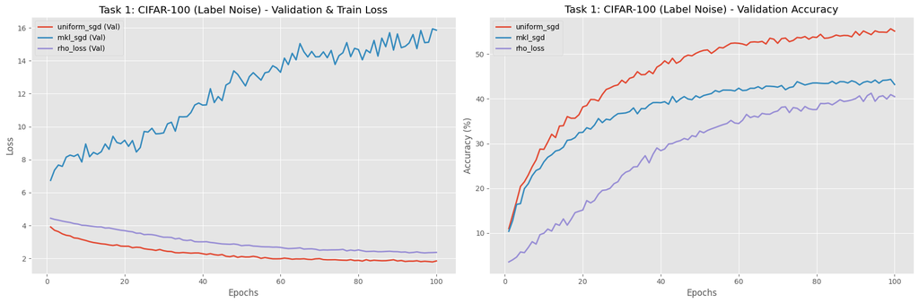

```
--- Task 1: CIFAR-100 (Label Noise) Summary Table ---
```

| Algorithm | Best Val Acc (%) | Epoch | Final Val Acc (%) | Final Train Acc (%) |
| --- | --- | --- | --- | --- |
| uniform_sgd | 55.63 | 99 | 55.11 | 44.84 |
| mkl_sgd | 44.33 | 99 | 43.19 | 39.15 |
| rho_loss | 41.24 | 94 | 40.48 | 29.34 |

```
##################################################
# ANALYSIS FOR: Task 2: MNIST (Input Noise)
##################################################
```

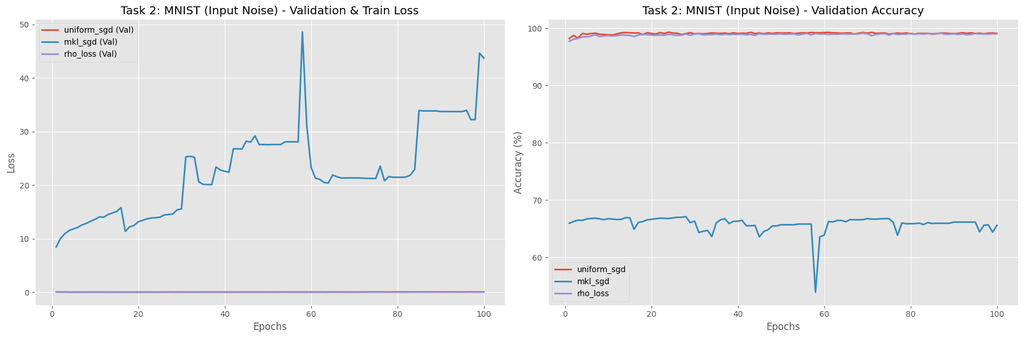

```
--- Task 2: MNIST (Input Noise) Summary Table ---
```

| Algorithm | Best Val Acc (%) | Epoch | Final Val Acc (%) | Final Train Acc (%) |
| --- | --- | --- | --- | --- |
| uniform_sgd | 99.34 | 24 | 99.10 | 99.94 |
| mkl_sgd | 67.11 | 28 | 65.60 | 64.00 |
| rho_loss | 99.17 | 87 | 99.03 | 99.55 |

```python
# --- 13. Run Analysis (All Experiments) ---
#
# !! RUN THIS CELL AFTER SNIPPET 11 IS DONE !!
#

print("--- Generating Full Analysis for All Tasks ---")

# Loop through each task we completed
for task_name, task_results_dict in all_experiment_results.items():

    print("\n" + "#"*50)
    print(f"# ANALYSIS FOR: {task_name}")
    print("#"*50)

    # 1. Extract the results and names for this task
    # (task_results_dict is e.g., {'uniform_sgd': {...}, 'mkl_sgd': {...}, ...})
    results_list = list(task_results_dict.values())
    algo_names = list(task_results_dict.keys())

    # 2. Generate the plots
    # (Uses the plot_results function from Snippet 12)
    plot_results(
        results_list,
        algo_names,
        title_prefix=task_name
    )

    # 3. Generate and display the summary table
    # (Uses the create_summary_table function from Snippet 12)
    summary_df = create_summary_table(results_list, algo_names)

    print(f"\n--- {task_name} Summary Table ---")
    display(summary_df)
    print("\n\n")
```